# Residue-residue distance in EDS on native structures.

- EDS variants vary in how Euclidean distance between (amino-acid) residues are calculated when finding EDS paths and identifying shortcut edges.
- The effects on shortcut edges and initial fold step of five EDS variants are examined:
  - CA-CA distance ('a', default, studied so far),
  - CB-CB distance ('b'),
  - shorter of CA-CA and CB-CB distance ('s'),
  - longer of CA-CA and CB-CB distance ('l'), and
  - mean CA-CA and CB-CB distance ('v').

```python
EDV = ['a', 'b', 's', 'l', 'v']
```

```python
import os
import numpy as np
import pandas as pd
import matplotlib.pyplot as plt
```

### Canonical set of single-domain protein chains used to study folding pathways.

```python
dirname = "SingleDomain"
PIDs = [ "2f4k", "1bdd", "2abd_0", "1gb1_0", "1mi0_swissmin", "1mhx_swissmin", "2ptl_0",
        "1shg", "1srm_1", "2ci2", "1aps_0", "2kjv_0", "2kjw_0", "1qys" ]
```

### Effect on number of shortcuts and number of long-range shortcuts.

- The number of edges and PRN0 contact map is identical for all EDS variants. The PRN0 construction method is not changed, only the distance used by EDS to construct paths is varied.

```python
fn = os.path.join(dirname, "NS_stats.out")
df = pd.read_table(fn, sep='\s+')
df = df[["pid", "numNodes", "numLinks", "numSC", "numSCLE"]]
x = df.pid.values
```

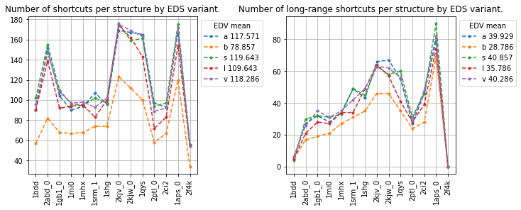

```python
fig, axes = plt.subplots(1, 2, figsize=(10, 4), constrained_layout=True)
ax1 = axes[0]; ax2 = axes[1];

ax1.set_title("Number of shortcuts per structure by EDS variant.")
ax1.plot(x, df.numSC.values, '.--', label='a' + ' ' + str(np.round(df.numSC.mean(), 3)))
ax2.set_title("Number of long-range shortcuts per structure by EDS variant.")
ax2.plot(x, df.numSCLE.values, '.--', label='a' + ' ' + str(np.round(df.numSCLE.mean(), 3)))

for v in EDV[1:]:
    fn = os.path.join(dirname, "NS_stats_" + v + ".out")
    df = pd.read_table(fn, sep='\s+')
    ax1.plot(x, df.numSC.values, '.--', label = v + ' ' + str(np.round(df.numSC.mean(), 3)))
    ax2.plot(x, df.numSCLE.values, '.--', label= v + ' ' + str(np.round(df.numSCLE.mean(), 3)))

# matplotlib 3.3.0
# https://stackoverflow.com/questions/63723514/userwarning-fixedformatter-should-only-be-used-together-with-fixedlocator
ax1.set_xticks(x); ax1.set_xticklabels(x, rotation=90); ax1.grid()
ax1.legend(title="EDV mean", loc='upper left', bbox_to_anchor=(1.0, 1.0))
ax2.set_xticks(x); ax2.set_xticklabels(x, rotation=90); ax2.grid()
_ = ax2.legend(title="EDV mean", loc='upper left', bbox_to_anchor=(1.0, 1.0))
```

- EDS variants 'a', 's', and 'v' produce roughly the same number of (long-range) shortcuts.
- EDS variants 'l' and 'b' produce fewer (long-range) shortcuts.
- Using CB-CB instead of CA-CA distances yield fewer (long-range) shortcuts.

```python
from scipy.stats import ttest_rel
def onesided_paired_ttest(a, b):
    stats, pval = ttest_rel(a, b) # two-sided paired ttest
    onesided_ttest_alt = ' < ' if stats < 0 else ' > '
    onesided_ttest_pval = pval/2
    return (onesided_ttest_alt, onesided_ttest_pval)
```

```python
# EDS may use distance between any residue pair, not just edges!
# compare CA-CA with CB-CB distances of edges (a sample)
CA_eds, CB_eds = [], []
for pid in PIDs:
    fn = os.path.join(dirname, pid + "_edges.out")
    da = pd.read_table(fn, sep='\s+')
    CA_eds.append(da.ed.mean())
    fn = os.path.join(dirname, pid + "_edges_b.out")
    db = pd.read_table(fn, sep='\s+')
    CB_eds.append(db.ed.mean())
    print(pid, np.round([da.ed.mean(), da.ed.std(), db.ed.mean(), db.ed.std()], 3))
```

```
2f4k [8.234 2.389 8.362 2.103]
1bdd [8.281 2.2   8.455 2.035]
2abd_0 [8.232 2.099 8.289 1.994]
1gb1_0 [8.079 2.113 8.147 1.966]
1mi0_swissmin [7.494 1.983 7.674 1.871]
1mhx_swissmin [7.271 1.803 7.454 1.682]
2ptl_0 [8.12  2.109 8.251 2.079]
1shg [7.308 1.798 7.385 1.68 ]
1srm_1 [8.068 1.983 8.077 1.881]
2ci2 [7.577 1.999 7.588 1.8  ]
1aps_0 [7.737 1.986 7.893 1.913]
2kjv_0 [8.269 2.148 8.316 1.956]
2kjw_0 [8.373 2.26  8.35  2.082]
1qys [7.294 1.834 7.445 1.656]
```

```
(' > ', 9.609018755856016e-05)
```

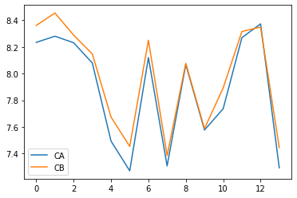

```python
# On average, CA-CA distances are significantly shorter than CB-CB distances.
print(onesided_paired_ttest(CB_eds, CA_eds))
plt.plot(CA_eds, label='CA')
plt.plot(CB_eds, label='CB')
_ = plt.legend();
```

- On average, CA-CA distances are significantly shorter than CB-CB distances.

### Effect on SCN0 contact map.

```python
# Plot the native-state contact map on the given axis,
# Black and red cells denote PRN0 edges and shortcuts, respectively.
import matplotlib.colors as matcol
def plot_NS_contactmap(cmwsc, ax):
    n, m = cmwsc.shape
    ax.imshow(cmwsc, origin="lower", cmap=matcol.ListedColormap(['white', 'black', 'red']))
    ax.set_xticks(np.arange(0, n, 10))
    ax.set_yticks(np.arange(0, m, 10))
```

```python
def plot_EDV_NScontactmaps(pid):
    fig1, axes1 = plt.subplots(2, 3, figsize=(9, 6), constrained_layout=True)
    fig1.suptitle("Native contact maps by EDS variant " + pid, fontsize=14)
    axes1[1][2].remove()
    for i, v in enumerate(EDV):
        if (v == 'a'):
            fn = os.path.join(dirname, pid + "_cmwsc.out")
        else:
            fn = os.path.join(dirname, pid + "_cmwsc_" + v + ".out")
        df = pd.read_table(fn, sep=' ', header=None)
        r = i//3; c = i%3; ax = axes1[r][c]
        plot_NS_contactmap(df.values, ax)
        ax.set_title("EDS variant " + v)
    plt.savefig("EDV_NAcontactmaps_" + pid + ".png")
    return
```

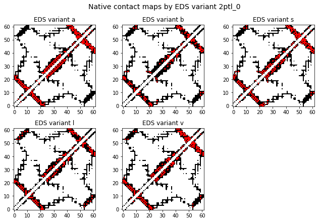

```python
plot_EDV_NScontactmaps("2ptl_0")
```

```python
# for interactivity
%matplotlib inline
from ipywidgets import interact
```

```python
_ = interact(plot_EDV_NScontactmaps, pid = PIDs)
```

### Effect on initial $C_{SCN0}$ fold step.

```python
def initial_foldstep(pid, edv):
    """Returns the initial pair of SSEs as a comma-separated string."""
    if edv == 'a':
        fn = os.path.join(dirname, pid + "_scn0_pathway.out")
    else:
        fn = os.path.join(dirname, pid + "_scn0_pathway_" + edv + ".out")
    df = pd.read_table(fn, sep='\t')
    configs = df.config.values
    combi = configs[1].split()
    first = [ e for e in combi if len(e) > 1 ][0] # get the string within the list
    return first
```

```python
# initial fold step by EDS variant
firsts_dict = {}
for pid in PIDs:
    firsts = [ initial_foldstep(pid, v) for v in EDV ]
    # print(pid, firsts)
    firsts_dict[pid] = firsts
df = pd.DataFrame(firsts_dict).transpose()
df.columns = EDV
df
```

|  | a | b | s | l | v |
| --- | --- | --- | --- | --- | --- |
| 2f4k | 1,3 | 3,5 | 3,5 | 1,3 | 3,5 |
| 1bdd | 3,5 | 3,5 | 3,5 | 3,5 | 3,5 |
| 2abd_0 | 5,7 | 3,5 | 1,3 | 3,5 | 1,3 |
| 1gb1_0 | 6,8 | 0,2 | 0,2 | 6,8 | 0,2 |
| 1mi0_swissmin | 1,3 | 1,3 | 1,3 | 1,3 | 1,3 |
| 1mhx_swissmin | 1,3 | 7,9 | 7,9 | 1,3 | 1,3 |
| 2ptl_0 | 0,2 | 6,8 | 0,2 | 6,8 | 6,8 |
| 1shg | 5,7 | 5,7 | 5,7 | 5,7 | 5,7 |
| 1srm_1 | 3,5 | 3,5 | 5,7 | 3,5 | 5,7 |
| 2ci2 | 5,7 | 5,7 | 5,7 | 5,7 | 5,7 |
| 1aps_0 | 5,7 | 9,11 | 5,7 | 5,7 | 5,7 |
| 2kjv_0 | 5,7 | 5,7 | 5,7 | 5,7 | 5,7 |
| 2kjw_0 | 5,7 | 5,7 | 5,7 | 5,7 | 5,7 |
| 1qys | 1,3 | 1,3 | 1,3 | 1,3 | 1,3 |

```python
# agreement with initial foldstep of EDS variant 'a'
agreefirst_df = pd.DataFrame(df.a)
for v in EDV[1:]:
    b = (df.a == df[v]) # series
    b.name = v
    agreefirst_df = agreefirst_df.join(b)
    print(v, b.sum())
agreefirst_df
```

```
b 8
s 9
l 12
v 9
```

|  | a | b | s | l | v |
| --- | --- | --- | --- | --- | --- |
| 2f4k | 1,3 | False | False | True | False |
| 1bdd | 3,5 | True | True | True | True |
| 2abd_0 | 5,7 | False | False | False | False |
| 1gb1_0 | 6,8 | False | False | True | False |
| 1mi0_swissmin | 1,3 | True | True | True | True |
| 1mhx_swissmin | 1,3 | False | False | True | True |
| 2ptl_0 | 0,2 | False | True | False | False |
| 1shg | 5,7 | True | True | True | True |
| 1srm_1 | 3,5 | True | False | True | False |
| 2ci2 | 5,7 | True | True | True | True |
| 1aps_0 | 5,7 | False | True | True | True |
| 2kjv_0 | 5,7 | True | True | True | True |
| 2kjw_0 | 5,7 | True | True | True | True |
| 1qys | 1,3 | True | True | True | True |

### End of notebook

SKLC September 2020